# Homework 1

## Daniel Toribio (100454242)

## Factory planning

### Introduction

We have been hired by a factory to optimize their production planning in order to maximize the total profit they can obtain by manufacturing and selling different products.

### Problem description

The factory makes 15 different products (these products can be produced in fractions). In order to make each product the factory needs to use different machines:

- Grinder
- Drill
- Lathe
- Milling
- Waterjet
- Presses
- Stamping

The factory has given to us a table where we can see the profit per unit in euros (sale price - the cost of materials) for each product. We are also given the time (in hours) needed for each product in each machine to be manufactured. The factory told us that the capacity of each machine is enought to be able to use it with different products at the same time.

|  | P1 | P2 | P3 | P4 | P5 | P6 | P7 | P8 | P9 | P10 | P11 | P12 | P13 | P14 | P15 |
| --- | --- | --- | --- | --- | --- | --- | --- | --- | --- | --- | --- | --- | --- | --- | --- |
| Profit | 2 | 8 | 8 | 5 | 7 | 9 | 12 | 17 | 13 | 6 | 3 | 11 | 4 | 15 | 4 |
| Grinding | 0.0012 |  | 0.0027 |  |  |  | 0.0078 |  |  |  | 0.0091 |  |  | 0.0032 | 0.0074 |
| Drilling | 0.0073 | 0.0021 |  | 0.0046 |  | 0.0081 |  | 0.0061 | 0.0034 |  | 0.0095 | 0.0018 |  | 0.0067 |  |
| Lathe |  | 0.0088 |  | 0.0025 | 0.0003 | 0.0068 | 0.0014 |  | 0.0085 |  |  |  |  |  |  |
| Milling |  |  | 0.0047 |  | 0.0007 |  | 0.0036 | 0.0006 |  |  | 0.0082 |  | 0.0094 |  |  |
| Waterjet cutters |  |  |  |  | 0.0021 | 0.0065 |  |  | 0.0007 | 0.0014 |  |  |  |  |  |
| Presses |  |  |  |  |  | 0.0029 |  | 0.0063 |  | 0.0043 | 0.0025 | 0.0056 |  |  |  |
| Stamping | 0.0033 | 0.0074 | 0.0002 | 0.0012 |  | 0.0055 |  | 0.0059 |  |  | 0.0083 |  | 0.0003 | 0.0041 | 0.0006 |

The products are stored in a warehouse for 0.2 euros each unit up to 3000 units int total.

The factory produces products five days per week with two shifts of eight hours per day. The last day of the month is used to sell the amount of products according to market limitations. Each month the total working hours are 3 weeks with 5 days with 16 hours each day plus the last week where only 4 days are used to produce and the last one to sell, so 3 *5* 16 + 4 * 16 = 304h

We have some limitations that do not allow us to sell more products in a given month according to this table:

| Month | Number of products |
| --- | --- |
| January | 10350 |
| February | 8550 |
| March | 7900 |
| April | 8850 |
| May | 14050 |
| June | 12250 |
| July | 15000 |
| August | 11800 |
| September | 9250 |
| October | 7750 |
| November | 12450 |
| December | 11050 |

We also need to satisfy a minimum demand of each product each month:

| Month | P1 | P2 | P3 | P4 | P5 | P6 | P7 | P8 | P9 | P10 | P11 | P12 | P13 | P14 | P15 |
| --- | --- | --- | --- | --- | --- | --- | --- | --- | --- | --- | --- | --- | --- | --- | --- |
| January | 79 | 87 | 161 | 141 | 141 | 103 | 186 | 110 | 71 | 106 | 85 | 180 | 68 | 68 | 196 |
| February | 85 | 141 | 107 | 132 | 84 | 142 | 83 | 64 | 88 | 182 | 185 | 129 | 174 | 100 | 186 |
| March | 188 | 127 | 52 | 193 | 138 | 101 | 148 | 89 | 180 | 54 | 89 | 68 | 126 | 54 | 166 |
| April | 53 | 196 | 141 | 139 | 55 | 145 | 83 | 185 | 146 | 182 | 66 | 198 | 108 | 92 | 96 |
| May | 188 | 188 | 145 | 182 | 60 | 50 | 64 | 50 | 145 | 130 | 63 | 79 | 132 | 180 | 162 |
| June | 60 | 64 | 153 | 108 | 195 | 131 | 142 | 166 | 89 | 89 | 124 | 116 | 197 | 125 | 118 |
| July | 65 | 166 | 50 | 104 | 169 | 105 | 154 | 169 | 155 | 196 | 138 | 67 | 103 | 194 | 131 |
| August | 159 | 84 | 95 | 159 | 200 | 121 | 170 | 77 | 79 | 193 | 162 | 142 | 156 | 168 | 106 |
| September | 154 | 199 | 59 | 170 | 60 | 186 | 170 | 200 | 144 | 82 | 140 | 97 | 172 | 187 | 60 |
| October | 112 | 200 | 177 | 181 | 84 | 153 | 174 | 62 | 92 | 191 | 102 | 50 | 143 | 118 | 132 |
| November | 173 | 87 | 180 | 84 | 77 | 198 | 111 | 123 | 116 | 170 | 127 | 107 | 87 | 54 | 64 |
| December | 155 | 145 | 169 | 162 | 123 | 118 | 148 | 102 | 98 | 91 | 181 | 180 | 87 | 165 | 63 |

There are limitations on how many of each product can be made in a given month because the providers of materials can not give to the factory more materials to make their products. These limits are shown below:

| Month | P1 | P2 | P3 | P4 | P5 | P6 | P7 | P8 | P9 | P10 | P11 | P12 | P13 | P14 | P15 |
| --- | --- | --- | --- | --- | --- | --- | --- | --- | --- | --- | --- | --- | --- | --- | --- |
| January | 900 | 800 | 650 | 500 | 550 | 1150 | 350 | 700 | 800 | 850 | 450 | 850 | 800 | 400 | 1150 |
| February | 450 | 250 | 650 | 100 | 450 | 700 | 550 | 800 | 650 | 900 | 450 | 100 | 150 | 1100 | 200 |
| March | 300 | 950 | 800 | 600 | 250 | 300 | 950 | 1400 | 950 | 1300 | 1350 | 700 | 700 | 550 | 1100 |
| April | 600 | 550 | 650 | 300 | 550 | 150 | 1150 | 650 | 1150 | 1000 | 500 | 1350 | 800 | 1400 | 650 |
| May | 700 | 100 | 600 | 550 | 700 | 850 | 750 | 750 | 1150 | 1000 | 750 | 1350 | 1450 | 1400 | 950 |
| June | 600 | 850 | 850 | 950 | 800 | 850 | 800 | 1050 | 600 | 650 | 1350 | 550 | 1400 | 800 | 1300 |
| July | 800 | 950 | 600 | 150 | 500 | 1150 | 750 | 600 | 700 | 500 | 1100 | 750 | 1050 | 1050 | 600 |
| August |  |  |  |  |  |  |  |  |  |  |  |  |  |  |  |
| September | 550 | 300 | 450 | 800 | 300 | 1100 | 550 | 1200 | 450 | 1200 | 1150 | 600 | 950 | 1150 | 1200 |
| October | 250 | 700 | 650 | 600 | 950 | 1300 | 1200 | 850 | 750 | 1050 | 1000 | 1050 | 900 | 850 | 750 |
| November | 250 | 950 | 250 | 100 | 750 | 150 | 100 | 750 | 1000 | 1300 | 750 | 800 | 600 | 1300 | 1000 |
| December | 950 | 650 | 950 | 700 | 1000 | 600 | 950 | 1050 | 700 | 700 | 1350 | 1000 | 1200 | 1350 | 1300 |

Note that in August there are no limits because the factory workers are on holidays and no products are made.

### Model formulation

#### Decision variables

We have to define indices to identify the decision variables:

\begin{equation} i \in \text{I}=\{1,2,\dots,15\}: \text{Set of products.} \end{equation}\begin{equation} j \in \text{J}=\{\text{Jan},\text{Feb},\dots,\text{Dec}\}: \text{Set of months.} \end{equation}\begin{equation} k \in \text{K}=\{\text{Grinder},\text{Drill},\dots,\text{Stamping}\}: \text{Set of machines.} \end{equation}

Firstly we have to identify what are the decision variables. In this problem we can make decisions in the number of products that will be produced each month, the number of products that will be sold each month, and the number of products that we are going to store in the warehouse each month.

\begin{equation} \text{make}_{i,j} \in \mathbb{R} : \text{Number of units of product i to make at month j.} \end{equation}\begin{equation} \text{sell}_{i,j} \in \mathbb{R} : \text{Number of units of product i to sell at month j.} \end{equation}\begin{equation} \text{store}_{i,j} \in \mathbb{R} : \text{Number of units of product i to store at month j.} \end{equation}

#### Objective Function

Once we have defined our decision variables we can define an objective function, in this case we want to maximize the total profit of the year:

\begin{equation} \text{Max} : \sum_{i}\sum_{j} (\text{profit}_i \times \text{sell}_{i,j} - \text{0.2} \times \text{store}_{i,j}) \end{equation}

#### Constraints

We have different constraints:

- For the first month, January, the number of units manufactured must be equal to the number of sold units plus the number of stored units. This coinstraint is necessary to avoid sending units that are not produced yet.

\begin{equation} \text{make}_{i,j} = \text{sell}_{i,j} + \text{store}_{i,j} \quad \forall i \in \text{I} \quad j = \text{Jan} \end{equation}

- For the rest of the months we also need to add a constraint about the balance to avoid sending units which do not exist. This can be modeled as the number of stored units of the previous year plus the number of manufactured units must be equal to the number of sold units plus the number of stored units each month. For this constraint we do not consider January.

\begin{equation} \text{store}_{i,j-1} + \text{make}_{i,j} = \text{sell}_{i,j} + \text{store}_{i,j} \quad \forall i \in \text{I} \quad \forall j \in \text{J} \setminus \{\text{Jan}\} \end{equation}

- We have to take care about the number of products, of each type, the factory can produce. I will refer to that limitation for product i on month j as make_limit_i,j.

\begin{equation} \text{make_limit}_{i,j} : \text{Maximum number of products i that can be made on month j.} \end{equation}\begin{equation} \text{make}_{i,j} \leq \text{make_limit}_{i,j} \quad \forall i \in \text{I} \quad \forall j \in \text{J} \end{equation}

- We have to consider the market limitations in the number of products that we are going to sell. For that I will refer to the limit for selling products on month j as sell_limit_j.

\begin{equation} \text{sell_limit}_{j} : \text{Maximum amount of products that can be sold on month j.} \end{equation}\begin{equation} \sum_{i}\text{sell}_{i,j} \leq \text{sell_limit}_{j} \quad \forall j \in \text{J} \end{equation}

- We need to satisfy the minimum demand of each product each month. For that I will define the minimum demand of product i at month j as demand_i,j.

\begin{equation} \text{demand}_{i,j} : \text{Minimum demand of product i at month j.} \end{equation}\begin{equation} \text{sell}_{i,j} \geq \text{demand}_{i,j} \quad \forall i \in \text{I} \quad \forall j \in \text{J} \end{equation}

- As we have a certain number of hours per month (304 hours) and each product needs a certain time to be made, the time required to manufacture the total number of products must be smaller or equal to the number of total working hours. To define in a compact way this constraint I will refer to the time to make product i with machine k as time_i,k.

\begin{equation} \text{time}_{i,k} : \text{Time required to make product i with machine k.} \end{equation}\begin{equation} \sum_{k}\text{time}_{i,k} \times \text{make}_{i,j} \leq \text{304} \quad \forall i \in \text{I} \quad \forall j \in \text{J} \end{equation}

\begin{equation} \sum_{i}\text{store}_{i,j} \leq \text{3000} \quad \forall j \in \text{J} \end{equation}

#### Defining the data

Before creating the model I will define the data of the problem.

```python
import numpy as np
import pandas as pd
from pyomo.environ import *
```

```python
Products = ["P1", "P2", "P3", "P4", "P5", "P6", "P7", "P8", "P9", "P10", "P11", "P12", "P13", "P14","P15"]
Machines = ["Grinder", "Drill", "Lathe", "Milling", "Waterjet", "Presses", "Stamping"]
Months = ["Jan", "Feb", "Mar", "Apr", "May", "Jun", "Jul", "Aug", "Sep", "Oct", "Nov", "Dec"]

profit = {"P1":2,
          "P2":8,
          "P3":8,
          "P4":5,
          "P5":7,
          "P6":9,
          "P7":12,
          "P8":17,
          "P9":13,
          "P10":6,
          "P11":3,
          "P12":11,
          "P13":4,
          "P14":15,
          "P15":4}

time = {
    ('P1', 'Grinder') : 0.0012,
    ('P2', 'Grinder') : 0,
    ('P3', 'Grinder') : 0.0027,
    ('P4', 'Grinder') : 0,
    ('P5', 'Grinder') : 0,
    ('P6', 'Grinder') : 0,
    ('P7', 'Grinder') : 0.0078,
    ('P8', 'Grinder') : 0,
    ('P9', 'Grinder') : 0,
    ('P10', 'Grinder') : 0,
    ('P11', 'Grinder') : 0.0091,
    ('P12', 'Grinder') : 0,
    ('P13', 'Grinder') : 0,
    ('P14', 'Grinder') : 0.0032,
    ('P15', 'Grinder') : 0.0074,
    ('P1', 'Drill') : 0.0073,
    ('P2', 'Drill') : 0.0021,
    ('P3', 'Drill') : 0,
    ('P4', 'Drill') : 0.0046,
    ('P5', 'Drill') : 0,
    ('P6', 'Drill') : 0.0081,
    ('P7', 'Drill') : 0,
    ('P8', 'Drill') : 0.0061,
    ('P9', 'Drill') : 0.0034,
    ('P10', 'Drill') : 0,
    ('P11', 'Drill') : 0.0095,
    ('P12', 'Drill') : 0.0018,
    ('P13', 'Drill') : 0,
    ('P14', 'Drill') : 0.0067,
    ('P15', 'Drill') : 0,
    ('P1', 'Lathe') : 0,
    ('P2', 'Lathe') : 0.0088,
    ('P3', 'Lathe') : 0,
    ('P4', 'Lathe') : 0.0025,
    ('P5', 'Lathe') : 0.0003,
    ('P6', 'Lathe') : 0.0068,
    ('P7', 'Lathe') : 0.0014,
    ('P8', 'Lathe') : 0,
    ('P9', 'Lathe') : 0.0085,
    ('P10', 'Lathe') : 0,
    ('P11', 'Lathe') : 0,
    ('P12', 'Lathe') : 0,
    ('P13', 'Lathe') : 0,
    ('P14', 'Lathe') : 0,
    ('P15', 'Lathe') : 0,
    ('P1', 'Milling') : 0,
    ('P2', 'Milling') : 0,
    ('P3', 'Milling') : 0.0047,
    ('P4', 'Milling') : 0,
    ('P5', 'Milling') : 0.007,
    ('P6', 'Milling') : 0,
    ('P7', 'Milling') : 0.0036,
    ('P8', 'Milling') : 0.0006,
    ('P9', 'Milling') : 0,
    ('P10', 'Milling') : 0,
    ('P11', 'Milling') : 0.0082,
    ('P12', 'Milling') : 0,
    ('P13', 'Milling') : 0.0094,
    ('P14', 'Milling') : 0,
    ('P15', 'Milling') : 0,
    ('P1', 'Waterjet') : 0,
    ('P2', 'Waterjet') : 0,
    ('P3', 'Waterjet') : 0,
    ('P4', 'Waterjet') : 0,
    ('P5', 'Waterjet') : 0.0021,
    ('P6', 'Waterjet') : 0.0065,
    ('P7', 'Waterjet') : 0,
    ('P8', 'Waterjet') : 0,
    ('P9', 'Waterjet') : 0.0007,
    ('P10', 'Waterjet') : 0.0014,
    ('P11', 'Waterjet') : 0,
    ('P12', 'Waterjet') : 0,
    ('P13', 'Waterjet') : 0,
    ('P14', 'Waterjet') : 0,
    ('P15', 'Waterjet') : 0,
    ('P1', 'Presses') : 0,
    ('P2', 'Presses') : 0,
    ('P3', 'Presses') : 0,
    ('P4', 'Presses') : 0,
    ('P5', 'Presses') : 0,
    ('P6', 'Presses') : 0.0029,
    ('P7', 'Presses') : 0,
    ('P8', 'Presses') : 0.0063,
    ('P9', 'Presses') : 0,
    ('P10', 'Presses') : 0.0043,
    ('P11', 'Presses') : 0.0025,
    ('P12', 'Presses') : 0.0056,
    ('P13', 'Presses') : 0,
    ('P14', 'Presses') : 0,
    ('P15', 'Presses') : 0,
    ('P1', 'Stamping') : 0.0033,
    ('P2', 'Stamping') : 0.0074,
    ('P3', 'Stamping') : 0.0002,
    ('P4', 'Stamping') : 0.0012,
    ('P5', 'Stamping') : 0,
    ('P6', 'Stamping') : 0.0055,
    ('P7', 'Stamping') : 0,
    ('P8', 'Stamping') : 0.0059,
    ('P9', 'Stamping') : 0,
    ('P10', 'Stamping') : 0,
    ('P11', 'Stamping') : 0.0083,
    ('P12', 'Stamping') : 0,
    ('P13', 'Stamping') : 0.0003,
    ('P14', 'Stamping') : 0.0041,
    ('P15', 'Stamping') : 0.0006
}
make_limit = {
    ("Jan", "P1") : 900,
    ("Jan", "P2") : 800,
    ("Jan", "P3") : 650,
    ("Jan", "P4") : 500,
    ("Jan", "P5") : 550,
    ("Jan", "P6") : 1150,
    ("Jan", "P7") : 350,
    ("Jan", "P8") : 700,
    ("Jan", "P9") : 800,
    ("Jan", "P10") : 850,
    ("Jan", "P11") : 450,
    ("Jan", "P12") : 850,
    ("Jan", "P13") : 800,
    ("Jan", "P14") : 400,
    ("Jan", "P15") : 1150,
    ("Feb", "P1") : 450,
    ("Feb", "P2") : 250,
    ("Feb", "P3") : 650,
    ("Feb", "P4") : 100,
    ("Feb", "P5") : 450,
    ("Feb", "P6") : 700,
    ("Feb", "P7") : 550,
    ("Feb", "P8") : 800,
    ("Feb", "P9") : 650,
    ("Feb", "P10") : 900,
    ("Feb", "P11") : 450,
    ("Feb", "P12") : 100,
    ("Feb", "P13") : 150,
    ("Feb", "P14") : 1100,
    ("Feb", "P15") : 200,
    ("Mar", "P1") : 300,
    ("Mar", "P2") : 950,
    ("Mar", "P3") : 800,
    ("Mar", "P4") : 600,
    ("Mar", "P5") : 250,
    ("Mar", "P6") : 300,
    ("Mar", "P7") : 950,
    ("Mar", "P8") : 1400,
    ("Mar", "P9") : 950,
    ("Mar", "P10") : 1300,
    ("Mar", "P11") : 1350,
    ("Mar", "P12") : 700,
    ("Mar", "P13") : 700,
    ("Mar", "P14") : 550,
    ("Mar", "P15") : 1100,
    ("Apr", "P1") : 600,
    ("Apr", "P2") : 550,
    ("Apr", "P3") : 650,
    ("Apr", "P4") : 300,
    ("Apr", "P5") : 550,
    ("Apr", "P6") : 150,
    ("Apr", "P7") : 1150,
    ("Apr", "P8") : 650,
    ("Apr", "P9") : 1150,
    ("Apr", "P10") : 1000,
    ("Apr", "P11") : 500,
    ("Apr", "P12") : 1350,
    ("Apr", "P13") : 800,
    ("Apr", "P14") : 1400,
    ("Apr", "P15") : 650,
    ("May", "P1") : 700,
    ("May", "P2") : 100,
    ("May", "P3") : 600,
    ("May", "P4") : 550,
    ("May", "P5") : 700,
    ("May", "P6") : 850,
    ("May", "P7") : 750,
    ("May", "P8") : 750,
    ("May", "P9") : 1150,
    ("May", "P10") : 1000,
    ("May", "P11") : 750,
    ("May", "P12") : 1350,
    ("May", "P13") : 1450,
    ("May", "P14") : 1400,
    ("May", "P15") : 950,
    ("Jun", "P1") : 600,
    ("Jun", "P2") : 850,
    ("Jun", "P3") : 850,
    ("Jun", "P4") : 950,
    ("Jun", "P5") : 800,
    ("Jun", "P6") : 850,
    ("Jun", "P7") : 800,
    ("Jun", "P8") : 1050,
    ("Jun", "P9") : 600,
    ("Jun", "P10") : 650,
    ("Jun", "P11") : 1350,
    ("Jun", "P12") : 550,
    ("Jun", "P13") : 1400,
    ("Jun", "P14") : 800,
    ("Jun", "P15") : 1300,
    ("Jul", "P1") : 800,
    ("Jul", "P2") : 950,
    ("Jul", "P3") : 600,
    ("Jul", "P4") : 150,
    ("Jul", "P5") : 500,
    ("Jul", "P6") : 1150,
    ("Jul", "P7") : 750,
    ("Jul", "P8") : 600,
    ("Jul", "P9") : 700,
    ("Jul", "P10") : 500,
    ("Jul", "P11") : 1100,
    ("Jul", "P12") : 750,
    ("Jul", "P13") : 1050,
    ("Jul", "P14") : 1050,
    ("Jul", "P15") : 600,
    ("Aug", "P1") : 0,
    ("Aug", "P2") : 0,
    ("Aug", "P3") : 0,
    ("Aug", "P4") : 0,
    ("Aug", "P5") : 0,
    ("Aug", "P6") : 0,
    ("Aug", "P7") : 0,
    ("Aug", "P8") : 0,
    ("Aug", "P9") : 0,
    ("Aug", "P10") : 0,
    ("Aug", "P11") : 0,
    ("Aug", "P12") : 0,
    ("Aug", "P13") : 0,
    ("Aug", "P14") : 0,
    ("Aug", "P15") : 0,
    ("Sep", "P1") : 550,
    ("Sep", "P2") : 300,
    ("Sep", "P3") : 450,
    ("Sep", "P4") : 800,
    ("Sep", "P5") : 300,
    ("Sep", "P6") : 1100,
    ("Sep", "P7") : 550,
    ("Sep", "P8") : 1200,
    ("Sep", "P9") : 450,
    ("Sep", "P10") : 1200,
    ("Sep", "P11") : 1150,
    ("Sep", "P12") : 600,
    ("Sep", "P13") : 950,
    ("Sep", "P14") : 1150,
    ("Sep", "P15") : 1200,
    ("Oct", "P1") : 250,
    ("Oct", "P2") : 700,
    ("Oct", "P3") : 650,
    ("Oct", "P4") : 600,
    ("Oct", "P5") : 950,
    ("Oct", "P6") : 1300,
    ("Oct", "P7") : 1200,
    ("Oct", "P8") : 850,
    ("Oct", "P9") : 750,
    ("Oct", "P10") : 1050,
    ("Oct", "P11") : 1000,
    ("Oct", "P12") : 1050,
    ("Oct", "P13") : 900,
    ("Oct", "P14") : 850,
    ("Oct", "P15") : 750,
    ("Nov", "P1") : 250,
    ("Nov", "P2") : 950,
    ("Nov", "P3") : 250,
    ("Nov", "P4") : 100,
    ("Nov", "P5") : 750,
    ("Nov", "P6") : 150,
    ("Nov", "P7") : 100,
    ("Nov", "P8") : 750,
    ("Nov", "P9") : 1000,
    ("Nov", "P10") : 1300,
    ("Nov", "P11") : 750,
    ("Nov", "P12") : 800,
    ("Nov", "P13") : 600,
    ("Nov", "P14") : 1300,
    ("Nov", "P15") : 1000,
    ("Dec", "P1") : 950,
    ("Dec", "P2") : 650,
    ("Dec", "P3") : 950,
    ("Dec", "P4") : 700,
    ("Dec", "P5") : 1000,
    ("Dec", "P6") : 600,
    ("Dec", "P7") : 950,
    ("Dec", "P8") : 1050,
    ("Dec", "P9") : 700,
    ("Dec", "P10") : 700,
    ("Dec", "P11") : 1350,
    ("Dec", "P12") : 1000,
    ("Dec", "P13") : 1200,
    ("Dec", "P14") : 1350,
    ("Dec", "P15") : 1300
}
```

```python
sell_limit = {"Jan" : 10350,
              "Feb" : 8550,
              "Mar" : 7900,
              "Apr" : 8850,
              "May" : 14050,
              "Jun" : 12250,
              "Jul" : 15000,
              "Aug" : 11800,
              "Sep" : 9250,
              "Oct" : 7750,
              "Nov" : 12450,
              "Dec" : 11050
}

demand = {
    ("Jan", "P1") : 79,
    ("Jan", "P2") : 87,
    ("Jan", "P3") : 161,
    ("Jan", "P4") : 141,
    ("Jan", "P5") : 141,
    ("Jan", "P6") : 103,
    ("Jan", "P7") : 186,
    ("Jan", "P8") : 110,
    ("Jan", "P9") : 71,
    ("Jan", "P10") : 106,
    ("Jan", "P11") : 85,
    ("Jan", "P12") : 180,
    ("Jan", "P13") : 68,
    ("Jan", "P14") : 68,
    ("Jan", "P15") : 196,
    ("Feb", "P1") : 85,
    ("Feb", "P2") : 141,
    ("Feb", "P3") : 107,
    ("Feb", "P4") : 132,
    ("Feb", "P5") : 84,
    ("Feb", "P6") : 142,
    ("Feb", "P7") : 83,
    ("Feb", "P8") : 64,
    ("Feb", "P9") : 88,
    ("Feb", "P10") : 182,
    ("Feb", "P11") : 185,
    ("Feb", "P12") : 129,
    ("Feb", "P13") : 174,
    ("Feb", "P14") : 100,
    ("Feb", "P15") : 186,
    ("Mar", "P1") : 188,
    ("Mar", "P2") : 127,
    ("Mar", "P3") : 52,
    ("Mar", "P4") : 193,
    ("Mar", "P5") : 138,
    ("Mar", "P6") : 101,
    ("Mar", "P7") : 148,
    ("Mar", "P8") : 89,
    ("Mar", "P9") : 180,
    ("Mar", "P10") : 54,
    ("Mar", "P11") : 89,
    ("Mar", "P12") : 68,
    ("Mar", "P13") : 126,
    ("Mar", "P14") : 54,
    ("Mar", "P15") : 166,
    ("Apr", "P1") : 53,
    ("Apr", "P2") : 196,
    ("Apr", "P3") : 141,
    ("Apr", "P4") : 139,
    ("Apr", "P5") : 55,
    ("Apr", "P6") : 145,
    ("Apr", "P7") : 83,
    ("Apr", "P8") : 185,
    ("Apr", "P9") : 146,
    ("Apr", "P10") : 182,
    ("Apr", "P11") : 66,
    ("Apr", "P12") : 198,
    ("Apr", "P13") : 108,
    ("Apr", "P14") : 92,
    ("Apr", "P15") : 96,
    ("May", "P1") : 188,
    ("May", "P2") : 188,
    ("May", "P3") : 145,
    ("May", "P4") : 182,
    ("May", "P5") : 60,
    ("May", "P6") : 50,
    ("May", "P7") : 64,
    ("May", "P8") : 50,
    ("May", "P9") : 145,
    ("May", "P10") : 130,
    ("May", "P11") : 63,
    ("May", "P12") : 79,
    ("May", "P13") : 132,
    ("May", "P14") : 180,
    ("May", "P15") : 162,
    ("Jun", "P1") : 60,
    ("Jun", "P2") : 64,
    ("Jun", "P3") : 153,
    ("Jun", "P4") : 108,
    ("Jun", "P5") : 195,
    ("Jun", "P6") : 131,
    ("Jun", "P7") : 142,
    ("Jun", "P8") : 166,
    ("Jun", "P9") : 89,
    ("Jun", "P10") : 89,
    ("Jun", "P11") : 124,
    ("Jun", "P12") : 116,
    ("Jun", "P13") : 197,
    ("Jun", "P14") : 125,
    ("Jun", "P15") : 118,
    ("Jul", "P1") : 65,
    ("Jul", "P2") : 166,
    ("Jul", "P3") : 50,
    ("Jul", "P4") : 104,
    ("Jul", "P5") : 169,
    ("Jul", "P6") : 105,
    ("Jul", "P7") : 154,
    ("Jul", "P8") : 169,
    ("Jul", "P9") : 155,
    ("Jul", "P10") : 196,
    ("Jul", "P11") : 138,
    ("Jul", "P12") : 67,
    ("Jul", "P13") : 103,
    ("Jul", "P14") : 194,
    ("Jul", "P15") : 131,
    ("Aug", "P1") : 159,
    ("Aug", "P2") : 84,
    ("Aug", "P3") : 95,
    ("Aug", "P4") : 159,
    ("Aug", "P5") : 200,
    ("Aug", "P6") : 121,
    ("Aug", "P7") : 170,
    ("Aug", "P8") : 77,
    ("Aug", "P9") : 79,
    ("Aug", "P10") : 193,
    ("Aug", "P11") : 162,
    ("Aug", "P12") : 142,
    ("Aug", "P13") : 156,
    ("Aug", "P14") : 168,
    ("Aug", "P15") : 106,
    ("Sep", "P1") : 154,
    ("Sep", "P2") : 199,
    ("Sep", "P3") : 59,
    ("Sep", "P4") : 170,
    ("Sep", "P5") : 60,
    ("Sep", "P6") : 186,
    ("Sep", "P7") : 170,
    ("Sep", "P8") : 200,
    ("Sep", "P9") : 144,
    ("Sep", "P10") : 82,
    ("Sep", "P11") : 140,
    ("Sep", "P12") : 97,
    ("Sep", "P13") : 172,
    ("Sep", "P14") : 187,
    ("Sep", "P15") : 60,
    ("Oct", "P1") : 112,
    ("Oct", "P2") : 200,
    ("Oct", "P3") : 177,
    ("Oct", "P4") : 181,
    ("Oct", "P5") : 84,
    ("Oct", "P6") : 153,
    ("Oct", "P7") : 174,
    ("Oct", "P8") : 62,
    ("Oct", "P9") : 92,
    ("Oct", "P10") : 191,
    ("Oct", "P11") : 102,
    ("Oct", "P12") : 50,
    ("Oct", "P13") : 143,
    ("Oct", "P14") : 118,
    ("Oct", "P15") : 132,
    ("Nov", "P1") : 173,
    ("Nov", "P2") : 87,
    ("Nov", "P3") : 180,
    ("Nov", "P4") : 84,
    ("Nov", "P5") : 77,
    ("Nov", "P6") : 198,
    ("Nov", "P7") : 111,
    ("Nov", "P8") : 123,
    ("Nov", "P9") : 116,
    ("Nov", "P10") : 170,
    ("Nov", "P11") : 127,
    ("Nov", "P12") : 107,
    ("Nov", "P13") : 87,
    ("Nov", "P14") : 54,
    ("Nov", "P15") : 64,
    ("Dec", "P1") : 155,
    ("Dec", "P2") : 145,
    ("Dec", "P3") : 169,
    ("Dec", "P4") : 162,
    ("Dec", "P5") : 123,
    ("Dec", "P6") : 118,
    ("Dec", "P7") : 148,
    ("Dec", "P8") : 102,
    ("Dec", "P9") : 98,
    ("Dec", "P10") : 91,
    ("Dec", "P11") : 181,
    ("Dec", "P12") : 180,
    ("Dec", "P13") : 87,
    ("Dec", "P14") : 165,
    ("Dec", "P15") : 63
}
```

### Exploratoy data analysis

Before creating a model, I will make some plots to understand better the data.

```python
import matplotlib.pyplot as plt
```

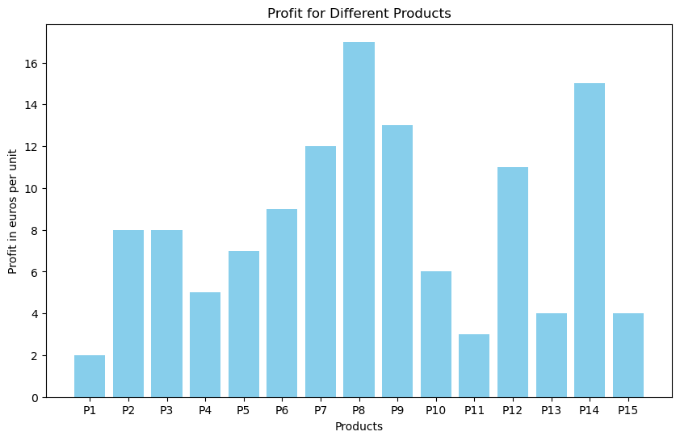

```python
products = list(profit.keys())
profits = list(profit.values())

# Create a bar plot
plt.figure(figsize=(10, 6))
plt.bar(products, profits, color='skyblue')
plt.xlabel('Products')
plt.ylabel('Profit in euros per unit')
plt.title('Profit for Different Products')


plt.show()
```

We can see that the product that gives us more profit is the P8, and that P1 is the one with lowest profit. We have to take care with this plot because we are not considering the time cost of each product.

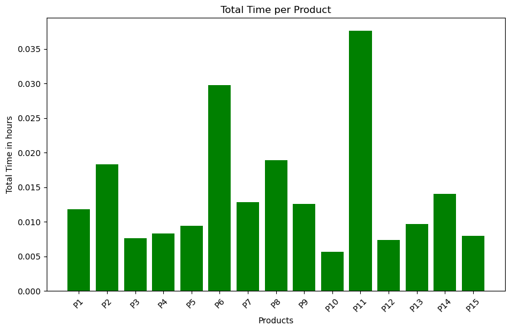

```python
# Create a dictionary to store the total time for each product
total_time_per_product = {}

for key, value in time.items():
    product = key[0]
    if product in total_time_per_product:
        total_time_per_product[product] += value
    else:
        total_time_per_product[product] = value

# Extract the product names and total times
products = list(total_time_per_product.keys())
total_times = list(total_time_per_product.values())

# Create a bar plot
plt.figure(figsize=(10, 6))
plt.bar(products, total_times, color='green')
plt.xlabel('Products')
plt.ylabel('Total Time in hours')
plt.title('Total Time per Product')
plt.xticks(rotation=45)  # Rotate x-axis labels for readability

plt.show()
```

With this bar plot we can see what products requires more time to be manufactured. P10 and P12 are very cheap in time cost, while P6 and P11 are the most expensive ones.

Now to see which ones gives more profit considering the time required for manufacturing them, we will plot the ratio between the profit and the time.

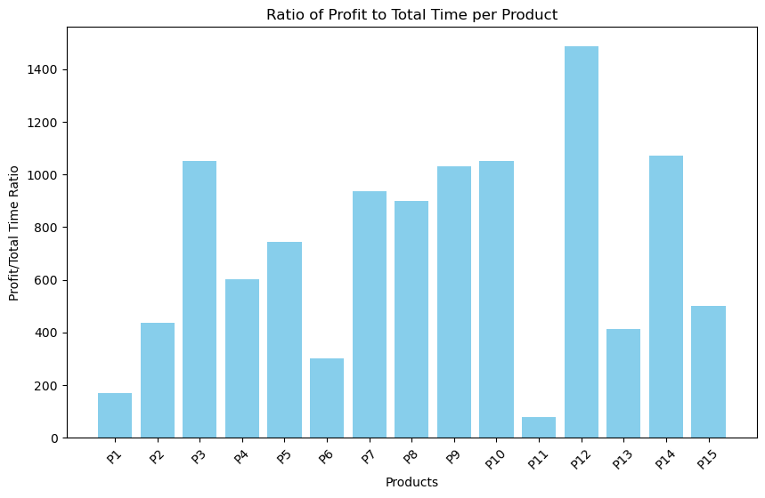

```python
profit_time_ratio = {}
for product in total_time_per_product:
    if product in profit:
        profit_time_ratio[product] = profit[product] / total_time_per_product[product]
    else:
        profit_time_ratio[product] = 0  # Set the ratio to 0 for products with no profit data

# Extract the product names and profit-to-time ratios
products = list(profit_time_ratio.keys())
ratios = list(profit_time_ratio.values())

# Create a bar plot for the profit-to-time ratios
plt.figure(figsize=(10, 6))
plt.bar(products, ratios, color='skyblue')
plt.xlabel('Products')
plt.ylabel('Profit/Total Time Ratio')
plt.title('Ratio of Profit to Total Time per Product')
plt.xticks(rotation=45)  # Rotate x-axis labels for readability

plt.show()
```

This plot gives us that the most profitable product is P12, and that P1 and P11 give small profit/time.

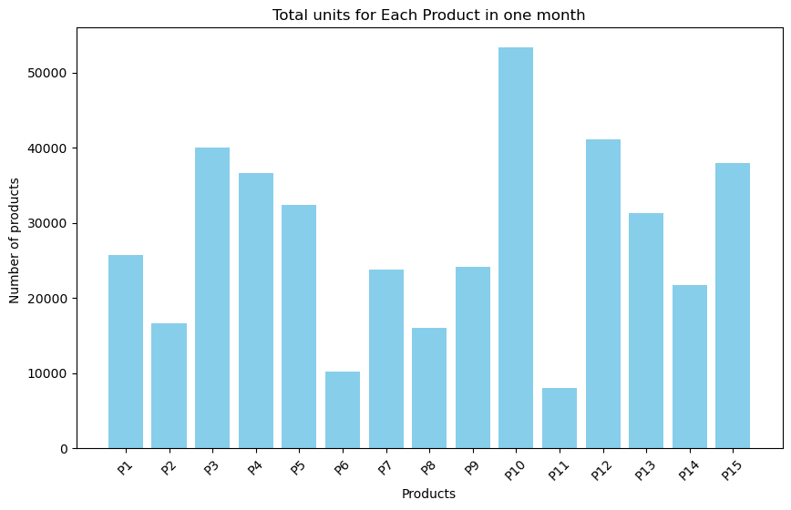

```python
total_units ={}

for product, time_value in total_time_per_product.items():
    total_units[product] =  304  / time_value

# Extract the product names and total times
products = list(total_units.keys())
total_units = list(total_units.values())

# Create a bar plot for the total time divided by 304
plt.figure(figsize=(10, 6))
plt.bar(products, total_units, color='skyblue')
plt.xlabel('Products')
plt.ylabel('Number of products ')
plt.title('Total units for Each Product in one month')
plt.xticks(rotation=45)  # Rotate x-axis labels for readability

plt.show()
```

Here we can see that we can make huge amounts of products of each type unless for P6 and P11 considering only the time cost and the number of hours per month.

We also have to see how much the material providers affects to the production each month.

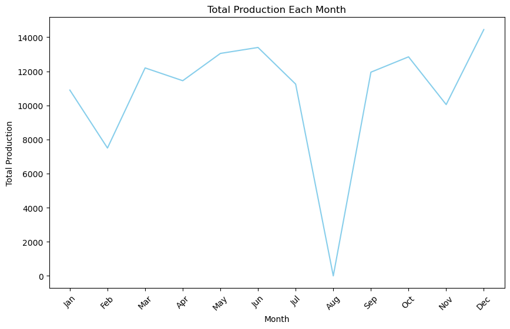

```python
# Create a dictionary to store the total production for each month
total_production_per_month = {}

for key, value in make_limit.items():
    month = key[0]
    if month in total_production_per_month:
        total_production_per_month[month] += value
    else:
        total_production_per_month[month] = value

# Extract the month names and total production values
months = list(total_production_per_month.keys())
production_values = list(total_production_per_month.values())

# Create a bar plot for the total production each month
plt.figure(figsize=(10, 6))
plt.plot(months, production_values, color='skyblue')
plt.xlabel('Month')
plt.ylabel('Total Production')
plt.title('Total Production Each Month')
plt.xticks(rotation=45)  # Rotate x-axis labels for readability

plt.show()
```

We can see that the total production changes a lot between months and it limitates a lot the production that can be made without provider constrains. In addition we can see that in August there is no production.

It will be interesting to see the minimum demand and the sell limitation.

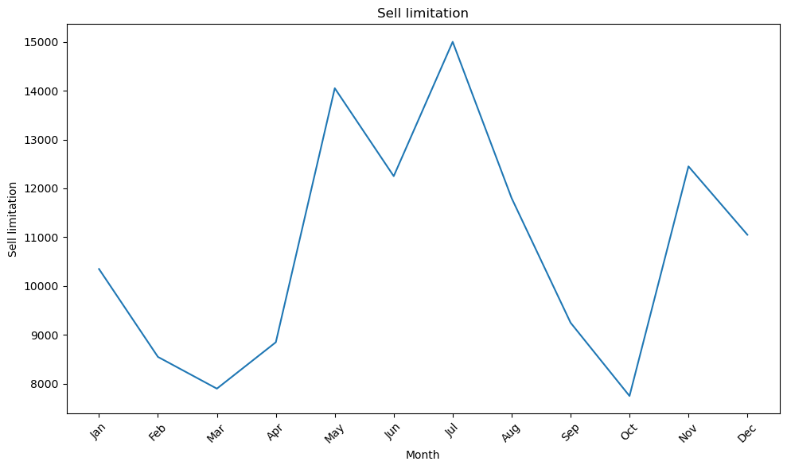

```python
months = list(sell_limit.keys())
limit = list(sell_limit.values())

# Calculate the total demand for each month

# Create a bar plot
plt.figure(figsize=(10, 6))
plt.plot(months, limit)
plt.xlabel("Month")
plt.ylabel("Sell limitation")
plt.title("Sell limitation")
plt.xticks(rotation=45)  # Rotate the x-axis labels for better visibility
plt.tight_layout()  # Adjust layout to prevent label clipping

# Display the plot
plt.show()
```

We can see that it varies a lot between months.

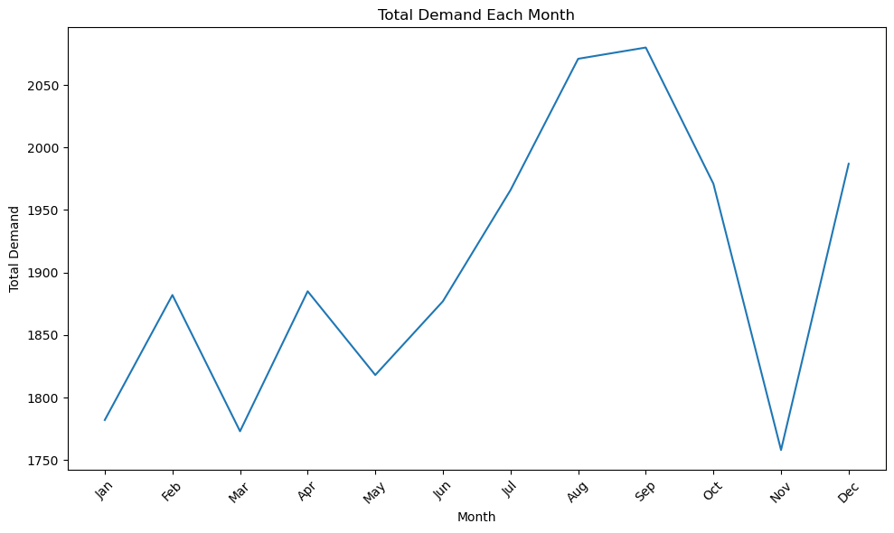

```python
total_demand_by_month = {}

for month, product_demand in demand.items():
    month_name = month[0]  # Extract the month from the key
    total_demand_by_month[month_name] = total_demand_by_month.get(month_name, 0) + product_demand

# Extract the months and their corresponding total demand values
months = list(total_demand_by_month.keys())
total_demand_values = list(total_demand_by_month.values())

# Create a bar plot
plt.figure(figsize=(10, 6))
plt.plot(months, total_demand_values)
plt.xlabel("Month")
plt.ylabel("Total Demand")
plt.title("Total Demand Each Month")
plt.xticks(rotation=45)  # Rotate the x-axis labels for better visibility
plt.tight_layout()  # Adjust layout to prevent label clipping

# Display the plot
plt.show()
```

For August and September we have the highest minimum demand. Now I will plot the maximum production each month with the maximum and minimum sell values.

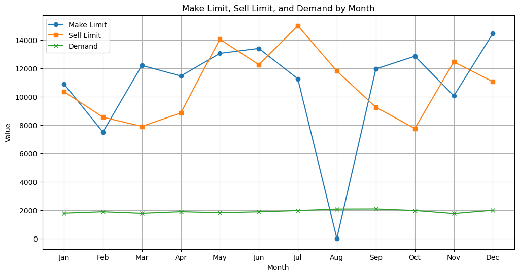

```python
plt.figure(figsize=(12, 6))
plt.plot(months, production_values, label='Make Limit', marker='o')
plt.plot(months, limit, label='Sell Limit', marker='s')
plt.plot(months, total_demand_values, label='Demand', marker='x')

# Add labels and legend
plt.xlabel('Month')
plt.ylabel('Value')
plt.title('Make Limit, Sell Limit, and Demand by Month')
plt.legend()

# Display the plot
plt.grid()
plt.show()
```

We can see that the minimum demand is going to be always satisfy. We have to take care in August as there is no production but we have a minimum demand so we have to store products in the warehouse.

### Model implementation

Once the model is formulated we just need to implement it in pyomo.First, we have to create the model, set the indices and then add to the model the decision variables, the objective function and the constraints.

```python
model = ConcreteModel("Linear model")
model.I = Set(initialize = Products, doc = "Products")
model.J = Set(initialize = Months, doc = 'Months')
model.K = Set(initialize = Machines, doc= "Machines")

model.Profit = Param(model.I, initialize = profit, doc="Profit")
model.Time = Param(model.I, model.K, initialize = time, doc = "Time")
model.Make_limit = Param(model.J, model.I, initialize = make_limit, doc="Make limit")
model.Sell_limit = Param(model.J, initialize = sell_limit, doc = "Sell limit")
model.Demand = Param(model.J, model.I, initialize = demand, doc = "Demand")

model.make = Var(model.I, model.J, doc='Units of product made', within=NonNegativeReals)
model.sell = Var(model.I, model.J, doc='Units of product sold', within=NonNegativeReals)
model.store = Var(model.I, model.J, doc='Units of product stored', within=NonNegativeReals)

def objective_rule(model):
    return sum(model.Profit[i]*model.sell[i,j]-0.2*model.store[i,j] for i in model.I for j in model.J)

model.objective = Objective(rule=objective_rule, sense=maximize, doc='Total profit')

def C1(model,i):
    return model.make[i,"Jan"] == model.sell[i,"Jan"] + model.store[i,"Jan"]

model.C1 = Constraint(model.I, rule=C1, doc='Initial balance')

def C2(model,i,j):
    return model.store[i,Months[Months.index(j)-1]] + model.make[i,j] == model.sell[i,j] + model.store[i,j]

model.C2 = Constraint(model.I, model.J, rule=C2, doc='General balance')

def C3(model,i,j):
    return model.make[i,j] <= model.Make_limit[j,i]

model.C3 = Constraint(model.I,model.J, rule=C3, doc='Make limit')

def C4(model,j):
    return sum(model.sell[i,j] for i in model.I) <= model.Sell_limit[j]

model.C4 = Constraint(model.J, rule=C4, doc='Sell limit')

def C5(model,i,j):
    return model.sell[i,j]  >= model.Demand[j,i]

model.C5 = Constraint(model.I,model.J, rule=C5, doc='Demand')

def C6(model,i,j):
    return sum(model.Time[i,k] * model.make[i,j] for k in model.K) <=304

model.C6 = Constraint(model.I,model.J, rule=C6, doc='Time limit')

def C7(model,j):
    return sum(model.store[i,j] for i in model.I) <= 3000

model.C7 = Constraint(model.J, rule=C7, doc='Store limit')
```

Once we have implemented the model, we have to solve it. I will use gurobi solver as it is faster than other solvers.

```python
Solver = SolverFactory('gurobi')
solution = Solver.solve(model)
```

### Analysis of the results

We have obtained the solution of our problem, this is, how many products of each type are going to be manufactured, how many sold and how many stored, in order to maximize the annual profit of the factory.

```python
model.make.display()
```

```
make : Units of product made
    Size=180, Index=make_index
    Key            : Lower : Value  : Upper : Fixed : Stale : Domain
     ('P1', 'Apr') :     0 :   53.0 :  None : False : False : NonNegativeReals
     ('P1', 'Aug') :     0 :    0.0 :  None : False : False : NonNegativeReals
     ('P1', 'Dec') :     0 :  155.0 :  None : False : False : NonNegativeReals
     ('P1', 'Feb') :     0 :  450.0 :  None : False : False : NonNegativeReals
     ('P1', 'Jan') :     0 :  900.0 :  None : False : False : NonNegativeReals
     ('P1', 'Jul') :     0 :  800.0 :  None : False : False : NonNegativeReals
     ('P1', 'Jun') :     0 :  600.0 :  None : False : False : NonNegativeReals
     ('P1', 'Mar') :     0 :  188.0 :  None : False : False : NonNegativeReals
     ('P1', 'May') :     0 :  550.0 :  None : False : False : NonNegativeReals
     ('P1', 'Nov') :     0 :  173.0 :  None : False : False : NonNegativeReals
     ('P1', 'Oct') :     0 :  112.0 :  None : False : False : NonNegativeReals
     ('P1', 'Sep') :     0 :  154.0 :  None : False : False : NonNegativeReals
    ('P10', 'Apr') :     0 : 1000.0 :  None : False : False : NonNegativeReals
    ('P10', 'Aug') :     0 :    0.0 :  None : False : False : NonNegativeReals
    ('P10', 'Dec') :     0 :  700.0 :  None : False : False : NonNegativeReals
    ('P10', 'Feb') :     0 :  900.0 :  None : False : False : NonNegativeReals
    ('P10', 'Jan') :     0 :  850.0 :  None : False : False : NonNegativeReals
    ('P10', 'Jul') :     0 :  500.0 :  None : False : False : NonNegativeReals
    ('P10', 'Jun') :     0 :  650.0 :  None : False : False : NonNegativeReals
    ('P10', 'Mar') :     0 : 1300.0 :  None : False : False : NonNegativeReals
    ('P10', 'May') :     0 : 1000.0 :  None : False : False : NonNegativeReals
    ('P10', 'Nov') :     0 : 1300.0 :  None : False : False : NonNegativeReals
    ('P10', 'Oct') :     0 : 1050.0 :  None : False : False : NonNegativeReals
    ('P10', 'Sep') :     0 : 1200.0 :  None : False : False : NonNegativeReals
    ('P11', 'Apr') :     0 :   66.0 :  None : False : False : NonNegativeReals
    ('P11', 'Aug') :     0 :    0.0 :  None : False : False : NonNegativeReals
    ('P11', 'Dec') :     0 :  181.0 :  None : False : False : NonNegativeReals
    ('P11', 'Feb') :     0 :  450.0 :  None : False : False : NonNegativeReals
    ('P11', 'Jan') :     0 :  450.0 :  None : False : False : NonNegativeReals
    ('P11', 'Jul') :     0 : 1100.0 :  None : False : False : NonNegativeReals
    ('P11', 'Jun') :     0 : 1350.0 :  None : False : False : NonNegativeReals
    ('P11', 'Mar') :     0 :   89.0 :  None : False : False : NonNegativeReals
    ('P11', 'May') :     0 :  750.0 :  None : False : False : NonNegativeReals
    ('P11', 'Nov') :     0 :  227.0 :  None : False : False : NonNegativeReals
    ('P11', 'Oct') :     0 :  102.0 :  None : False : False : NonNegativeReals
    ('P11', 'Sep') :     0 :  140.0 :  None : False : False : NonNegativeReals
    ('P12', 'Apr') :     0 : 1350.0 :  None : False : False : NonNegativeReals
```

[output cut: 128 more lines]

```
     ('P8', 'Nov') :     0 :  750.0 :  None : False : False : NonNegativeReals
     ('P8', 'Oct') :     0 :  850.0 :  None : False : False : NonNegativeReals
     ('P8', 'Sep') :     0 : 1200.0 :  None : False : False : NonNegativeReals
     ('P9', 'Apr') :     0 : 1150.0 :  None : False : False : NonNegativeReals
     ('P9', 'Aug') :     0 :    0.0 :  None : False : False : NonNegativeReals
     ('P9', 'Dec') :     0 :  700.0 :  None : False : False : NonNegativeReals
     ('P9', 'Feb') :     0 :  650.0 :  None : False : False : NonNegativeReals
     ('P9', 'Jan') :     0 :  800.0 :  None : False : False : NonNegativeReals
     ('P9', 'Jul') :     0 :  700.0 :  None : False : False : NonNegativeReals
     ('P9', 'Jun') :     0 :  600.0 :  None : False : False : NonNegativeReals
     ('P9', 'Mar') :     0 :  950.0 :  None : False : False : NonNegativeReals
     ('P9', 'May') :     0 : 1150.0 :  None : False : False : NonNegativeReals
     ('P9', 'Nov') :     0 : 1000.0 :  None : False : False : NonNegativeReals
     ('P9', 'Oct') :     0 :  750.0 :  None : False : False : NonNegativeReals
     ('P9', 'Sep') :     0 :  450.0 :  None : False : False : NonNegativeReals
```

I will use pandas to see the results in a table, which will be easier to understand.

```python
make = pd.DataFrame()

for i in model.I:
    for j in model.J:
        make.loc[i,j] = model.make[i,j]()


print(make)
```

```
        Jan     Feb     Mar     Apr     May     Jun     Jul  Aug     Sep  \
P1    900.0   450.0   188.0    53.0   550.0   600.0   800.0  0.0   154.0
P2    800.0   250.0   950.0   550.0   100.0   850.0   950.0  0.0   300.0
P3    650.0   650.0   800.0   650.0   600.0   850.0   600.0  0.0   450.0
P4    500.0   100.0   600.0   300.0   550.0   950.0   150.0  0.0   800.0
P5    550.0   450.0   250.0   550.0   700.0   800.0   500.0  0.0   300.0
P6   1150.0   700.0   300.0   150.0   850.0   850.0  1150.0  0.0  1100.0
P7    350.0   550.0   950.0  1150.0   750.0   800.0   750.0  0.0   550.0
P8    700.0   800.0  1400.0   650.0   750.0  1050.0   600.0  0.0  1200.0
P9    800.0   650.0   950.0  1150.0  1150.0   600.0   700.0  0.0   450.0
P10   850.0   900.0  1300.0  1000.0  1000.0   650.0   500.0  0.0  1200.0
P11   450.0   450.0    89.0    66.0   750.0  1350.0  1100.0  0.0   140.0
P12   850.0   100.0   700.0  1350.0  1350.0   550.0   750.0  0.0   600.0
P13   800.0   150.0   126.0   800.0  1450.0  1400.0  1050.0  0.0   172.0
P14   400.0  1100.0   550.0  1400.0  1400.0   800.0  1050.0  0.0  1150.0
P15  1150.0   200.0   166.0   612.0   950.0  1300.0   600.0  0.0   684.0

        Oct     Nov     Dec
P1    112.0   173.0   155.0
P2    700.0   950.0   650.0
P3    650.0   250.0   950.0
P4    600.0   100.0   700.0
P5    950.0   750.0  1000.0
P6   1300.0   150.0   600.0
P7   1200.0   100.0   950.0
P8    850.0   750.0  1050.0
P9    750.0  1000.0   700.0
P10  1050.0  1300.0   700.0
P11   102.0   227.0   181.0
P12  1050.0   800.0  1000.0
P13   143.0   600.0    87.0
P14   850.0  1300.0  1350.0
P15   443.0  1000.0   977.0
```

I will do the same for the sell and store results.

```python
sell = pd.DataFrame()

for i in model.I:
    for j in model.J:
        sell.loc[i,j] = model.sell[i,j]()


print(sell)
```

```
        Jan     Feb     Mar     Apr     May     Jun     Jul    Aug     Sep  \
P1    900.0   450.0   188.0    53.0   550.0   600.0   641.0  159.0   154.0
P2    800.0   250.0   950.0   196.0   454.0   850.0   866.0   84.0   300.0
P3    650.0   650.0   627.0   823.0   600.0   850.0   505.0   95.0   450.0
P4    468.0   132.0   600.0   300.0   550.0   108.0   833.0  159.0   800.0
P5    550.0   450.0   250.0   550.0   700.0   800.0   300.0  200.0   300.0
P6   1150.0   700.0   300.0   150.0   850.0   850.0  1029.0  121.0  1100.0
P7    186.0   714.0   950.0  1150.0   750.0   800.0   580.0  170.0   550.0
P8    700.0   800.0  1400.0   292.0  1108.0  1050.0   523.0   77.0  1200.0
P9    800.0   650.0   950.0  1150.0  1150.0   600.0   621.0   79.0   450.0
P10   850.0   900.0    54.0  1266.0   130.0   342.0  2465.0  193.0  1200.0
P11   450.0   450.0    89.0    66.0   750.0  1350.0   938.0  162.0   140.0
P12   821.0   129.0   700.0  1350.0  1350.0   550.0   608.0  142.0   600.0
P13   776.0   174.0   126.0   800.0  1450.0  1400.0   894.0  156.0   172.0
P14    99.0  1401.0   550.0    92.0  2708.0   800.0   882.0  168.0  1150.0
P15  1150.0   200.0   166.0   612.0   950.0  1300.0   494.0  106.0   684.0

        Oct     Nov     Dec
P1    112.0   173.0   155.0
P2    700.0   950.0   650.0
P3    650.0   250.0   950.0
P4    600.0   100.0   700.0
P5    950.0   750.0  1000.0
P6    153.0  1297.0   600.0
P7    174.0  1126.0   950.0
P8    755.0   845.0  1050.0
P9    750.0  1000.0   700.0
P10  1050.0  1300.0   700.0
P11   102.0   227.0   181.0
P12  1050.0   800.0  1000.0
P13   143.0   600.0    87.0
P14   118.0  2032.0  1350.0
P15   443.0  1000.0   977.0
```

```python
store = pd.DataFrame()

for i in model.I:
    for j in model.J:
        store.loc[i,j] = model.store[i,j]()


print(store)
```

```
       Jan  Feb     Mar     Apr     May     Jun    Jul  Aug  Sep     Oct  Nov  \
P1     0.0  0.0     0.0     0.0     0.0     0.0  159.0  0.0  0.0     0.0  0.0
P2     0.0  0.0     0.0   354.0     0.0     0.0   84.0  0.0  0.0     0.0  0.0
P3     0.0  0.0   173.0     0.0     0.0     0.0   95.0  0.0  0.0     0.0  0.0
P4    32.0  0.0     0.0     0.0     0.0   842.0  159.0  0.0  0.0     0.0  0.0
P5     0.0  0.0     0.0     0.0     0.0     0.0  200.0  0.0  0.0     0.0  0.0
P6     0.0  0.0     0.0     0.0     0.0     0.0  121.0  0.0  0.0  1147.0  0.0
P7   164.0  0.0     0.0     0.0     0.0     0.0  170.0  0.0  0.0  1026.0  0.0
P8     0.0  0.0     0.0   358.0     0.0     0.0   77.0  0.0  0.0    95.0  0.0
P9     0.0  0.0     0.0     0.0     0.0     0.0   79.0  0.0  0.0     0.0  0.0
P10    0.0  0.0  1246.0   980.0  1850.0  2158.0  193.0  0.0  0.0     0.0  0.0
P11    0.0  0.0     0.0     0.0     0.0     0.0  162.0  0.0  0.0     0.0  0.0
P12   29.0  0.0     0.0     0.0     0.0     0.0  142.0  0.0  0.0     0.0  0.0
P13   24.0  0.0     0.0     0.0     0.0     0.0  156.0  0.0  0.0     0.0  0.0
P14  301.0  0.0     0.0  1308.0     0.0     0.0  168.0  0.0  0.0   732.0  0.0
P15    0.0  0.0     0.0     0.0     0.0     0.0  106.0  0.0  0.0     0.0  0.0

     Dec
P1   0.0
P2   0.0
P3   0.0
P4   0.0
P5   0.0
P6   0.0
P7   0.0
P8   0.0
P9   0.0
P10  0.0
P11  0.0
P12  0.0
P13  0.0
P14  0.0
P15  0.0
```

With this solution we can see that for example we will manufacture 500 units of product P4, sell 468 units of them and store 32 units.

```python
model.objective()
```

```
1054247.0
```

The maximum profit we can obtain is 1.054.247 €

We can make plots to understand better the solution.

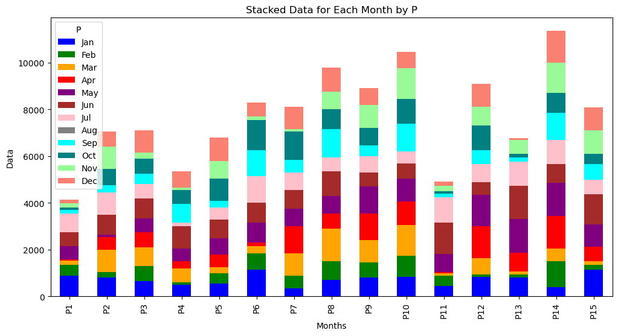

```python
# Create a stacked bar plot for each month
custom_colors = ['blue', 'green', 'orange', 'red', 'purple', 'brown', 'pink', 'gray', 'cyan', 'teal', 'palegreen', 'salmon', 'peru']
make.plot(kind='bar', stacked=True, figsize=(12, 6), color=custom_colors)

plt.xlabel('Months')
plt.ylabel('Data')
plt.title('Stacked Data for Each Month by P')
plt.legend(title='P')

# Display the plot
plt.show()
```

With our solution, we can see that we will manufacture a lot of units of P14 along the year, specially in April, May, November and December.

```python
# Agregar una columna 'Total' que contenga la suma de la producción de todos los tipos de productos por mes
make_transposed = make.transpose()
make_transposed['Total'] = make_transposed.sum(axis=1)

sell_transposed = sell.transpose()
sell_transposed['Total'] = sell_transposed.sum(axis=1)

store_transposed = store.transpose()
store_transposed['Total'] = store_transposed.sum(axis=1)
```

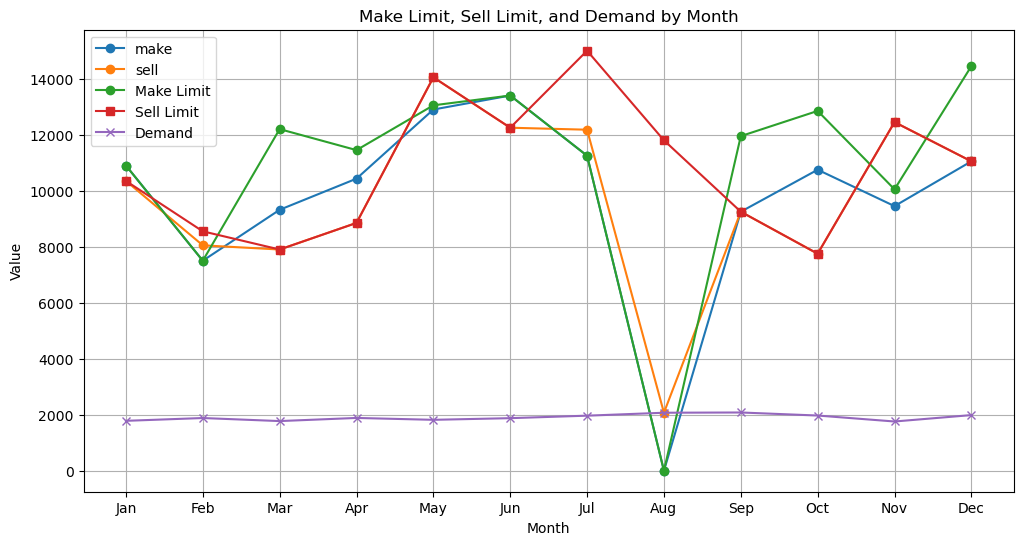

```python
plt.figure(figsize=(12, 6))
plt.plot(make_transposed.index, make_transposed['Total'], label='make', marker='o')
plt.plot(sell_transposed.index, sell_transposed['Total'], label='sell', marker='o')
plt.plot(months, production_values, label='Make Limit', marker='o')
plt.plot(months, limit, label='Sell Limit', marker='s')
plt.plot(months, total_demand_values, label='Demand', marker='x')

# Add labels and legend
plt.xlabel('Month')
plt.ylabel('Value')
plt.title('Make Limit, Sell Limit, and Demand by Month')
plt.legend()

# Display the plot
plt.grid()
plt.show()
```

Here we can see that our solutions related with the production and selling the products are between the constraints. Now I will check that the balance is correct.

```python
check = pd.DataFrame()
check = make.add(store.shift(axis=1), fill_value=0)
check2 = pd.DataFrame()
check2 = sell.add(store)
print(check-check2)
```

```
     Jan  Feb  Mar  Apr  May  Jun  Jul  Aug  Sep  Oct  Nov  Dec
P1   0.0  0.0  0.0  0.0  0.0  0.0  0.0  0.0  0.0  0.0  0.0  0.0
P2   0.0  0.0  0.0  0.0  0.0  0.0  0.0  0.0  0.0  0.0  0.0  0.0
P3   0.0  0.0  0.0  0.0  0.0  0.0  0.0  0.0  0.0  0.0  0.0  0.0
P4   0.0  0.0  0.0  0.0  0.0  0.0  0.0  0.0  0.0  0.0  0.0  0.0
P5   0.0  0.0  0.0  0.0  0.0  0.0  0.0  0.0  0.0  0.0  0.0  0.0
P6   0.0  0.0  0.0  0.0  0.0  0.0  0.0  0.0  0.0  0.0  0.0  0.0
P7   0.0  0.0  0.0  0.0  0.0  0.0  0.0  0.0  0.0  0.0  0.0  0.0
P8   0.0  0.0  0.0  0.0  0.0  0.0  0.0  0.0  0.0  0.0  0.0  0.0
P9   0.0  0.0  0.0  0.0  0.0  0.0  0.0  0.0  0.0  0.0  0.0  0.0
P10  0.0  0.0  0.0  0.0  0.0  0.0  0.0  0.0  0.0  0.0  0.0  0.0
P11  0.0  0.0  0.0  0.0  0.0  0.0  0.0  0.0  0.0  0.0  0.0  0.0
P12  0.0  0.0  0.0  0.0  0.0  0.0  0.0  0.0  0.0  0.0  0.0  0.0
P13  0.0  0.0  0.0  0.0  0.0  0.0  0.0  0.0  0.0  0.0  0.0  0.0
P14  0.0  0.0  0.0  0.0  0.0  0.0  0.0  0.0  0.0  0.0  0.0  0.0
P15  0.0  0.0  0.0  0.0  0.0  0.0  0.0  0.0  0.0  0.0  0.0  0.0
```

We can see that the balance is fine for every product each month.

### Sensitivities

```python
model.dual = Suffix(direction = Suffix.IMPORT)
Results = Solver.solve(model)
```

```python
model.dual.display()
```

```
dual : Direction=Suffix.IMPORT, Datatype=Suffix.FLOAT
    Key         : Value
        C1[P10] :     -5.800000000000001
        C1[P11] :    -2.8000000000000007
        C1[P12] :                  -10.8
        C1[P13] :    -3.8000000000000007
        C1[P14] :                  -14.8
        C1[P15] :    -3.8000000000000007
         C1[P1] :    -1.8000000000000007
         C1[P2] :     -7.800000000000001
         C1[P3] :     -7.800000000000001
         C1[P4] :     -4.800000000000001
         C1[P5] :     -6.800000000000001
         C1[P6] :                   -8.8
         C1[P7] :                  -11.8
         C1[P8] :                  -16.8
         C1[P9] :                  -12.8
     C2[P1,Apr] :                   -0.0
     C2[P1,Aug] :                   -2.2
     C2[P1,Dec] :                   -0.0
     C2[P1,Feb] :                   -2.0
     C2[P1,Jan] :                    0.0
     C2[P1,Jul] :                   -2.0
     C2[P1,Jun] :   -0.20000000000000107
     C2[P1,Mar] :                   -0.0
     C2[P1,May] :                   -0.0
     C2[P1,Nov] :                   -0.0
     C2[P1,Oct] :                   -0.0
     C2[P1,Sep] :                   -0.0
    C2[P10,Apr] :                   -2.0
    C2[P10,Aug] :                   -6.2
    C2[P10,Dec] :                   -2.0
    C2[P10,Feb] :                   -6.0
    C2[P10,Jan] :                    0.0
    C2[P10,Jul] :                   -6.0
    C2[P10,Jun] :     -4.200000000000001
    C2[P10,Mar] :                   -1.8
    C2[P10,May] :     -4.000000000000001
    C2[P10,Nov] :                   -3.0
    C2[P10,Oct] :                   -2.0
```

[output cut: 706 more lines]

```
     C6[P9,Nov] :                    0.0
     C6[P9,Oct] :                    0.0
     C6[P9,Sep] :                    0.0
        C7[Apr] :     1.8000000000000007
        C7[Aug] :                    0.0
        C7[Dec] :                    0.0
        C7[Feb] :                    0.0
        C7[Jan] :                    0.0
        C7[Jul] :                    0.0
        C7[Jun] :     1.5999999999999988
        C7[Mar] :                    0.0
        C7[May] :                    0.0
        C7[Nov] :                    0.0
        C7[Oct] :     0.8000000000000007
        C7[Sep] :                    0.0
```

```python
max_entry = None
max_value = float('-inf')  # Start with negative infinity as the initial maximum value

for key, value in model.dual.items():
    if value > max_value:
        max_value = value
        max_entry = key

print(f"The entry with the maximum value is: {max_entry} with a value of {max_value}")
```

```
The entry with the maximum value is: C3[P8,Aug] with a value of 17.2
```

```python
top_entries = []

# Iterate through the data to find the top 5 entries
for key, value in model.dual.items():
    if len(top_entries) < 5:
        # If the list is not full, add the current entry
        top_entries.append((key, value))
        # Sort the list based on values in descending order
        top_entries.sort(key=lambda x: x[1], reverse=True)
    else:
        # If the list is full, compare the current entry with the smallest entry in the list
        if value > top_entries[-1][1]:
            # Replace the smallest entry with the current entry
            top_entries[-1] = (key, value)
            # Sort the list again based on values in descending order
            top_entries.sort(key=lambda x: x[1], reverse=True)

print("The top 5 entries with the highest values are:")
for entry, value in top_entries:
    print(f"{entry}: {value}")
```

```
The top 5 entries with the highest values are:
C3[P8,Aug]: 17.2
C3[P8,Feb]: 17.0
C3[P8,Jul]: 17.0
C3[P8,Jan]: 16.8
C3[P8,Jun]: 15.200000000000001
```

After computing the sensitivities we can see that the constraint that most affects the profit is the one related with the limitation in production, and specially for product 8 in August, February, and July. This means that if we are able to increase the production we must choose to increase product 8 in February or in July. We have to take care because the other constraint that gives us the highest profit is if we increase the production in August but in that month the factory does not produce. Now I will construct a new model increasing this constraint to be able to see that it increases the profit by 17 euros per unit.

```python
model2 = ConcreteModel("Linear model2 with sensitivities")
model2.I = Set(initialize = Products, doc = "Products")
model2.J = Set(initialize = Months, doc = 'Months')
model2.M = Set(initialize = Machines, doc= "Machines")

model2.Profit = Param(model2.I, initialize = profit, doc="Profit")
model2.Time = Param(model2.I, model2.M, initialize = time, doc = "Time")
model2.Make_limit = Param(model2.J, model2.I, initialize = make_limit, doc="Make limit")
model2.Sell_limit = Param(model2.J, initialize = sell_limit, doc = "Sell limit")
model2.Demand = Param(model2.J, model2.I, initialize = demand, doc = "Demand")

model2.make = Var(model2.I, model2.J, doc='Units of product made', within=NonNegativeReals)
model2.sell = Var(model2.I, model2.J, doc='Units of product sold', within=NonNegativeReals)
model2.store = Var(model2.I, model2.J, doc='Units of product stored', within=NonNegativeReals)

def objective_rule(model2):
    return sum(model2.Profit[i]*model2.sell[i,j]-0.2*model2.store[i,j] for i in model2.I for j in model2.J)

model2.objective = Objective(rule=objective_rule, sense=maximize, doc='Total profit')

def C1(model2,i):
    return model2.make[i,"Jan"] == model2.sell[i,"Jan"] + model2.store[i,"Jan"]

model2.C1 = Constraint(model2.I, rule=C1, doc='Initial balance')

def C2(model2,i,j):
    return model2.store[i,Months[Months.index(j)-1]] + model2.make[i,j]  == model2.sell[i,j] + model2.store[i,j]

model2.C2 = Constraint(model2.I, model2.J, rule=C2, doc='General balance')

def C3(model2,i,j):
    if (i=="P8" and j=="Feb"): #This is the sensitivity that gives us the highest profit
        return model2.make[i,j] <= model2.Make_limit[j,i] + 1
    else:
        return model2.make[i,j] <= model2.Make_limit[j,i]

model2.C3 = Constraint(model2.I, model2.J, rule=C3, doc='Make limit')

def C5(model2,j):
    return sum(model2.sell[i,j] for i in model2.I) <= model2.Sell_limit[j]

model2.C5 = Constraint(model2.J, rule=C5, doc='Sell limit')

def C6(model2,i,j):
    return model2.sell[i,j]  >= model2.Demand[j,i]

model2.C6 = Constraint(model2.I,model2.J, rule=C6, doc='Sell limit')

def C7(model2,j):
    return sum(model2.store[i,j] for i in model2.I) <= 3000

model2.C7 = Constraint(model2.J, rule=C7, doc='Store limit')
```

```python
Solver = SolverFactory('gurobi')
solution = Solver.solve(model2)
```

```python
print("Without increasing production: ",round(model.objective()),"€")
print("Increasing production: ",round(model2.objective()),"€")
print("It has increased: ", round(model2.objective() - model.objective() ),"€")
```

```
Without increasing production:  1054247 €
Increasing production:  1054264 €
It has increased:  17 €
```

```python
sell2 = pd.DataFrame()

for i in model.I:
    for j in model.J:
        sell2.loc[i,j] = model2.sell[i,j]()

print(sell.loc["P8","Feb"])
print(sell2.loc["P8","Feb"])
```

```
800.0
801.0
```

We can see that if we increase by one unit the total production for product 8 in February we increase the total profit by 17 €, which make sense since we have sold one more unit of product 8 whose profit per unit is 17 €.

```python
min_entry = None
min_value = float('inf')  # Start with negative infinity as the initial maximum value

for key, value in model.dual.items():
    if value < min_value:
        min_value = value
        min_entry = key

print(f"The entry with the minimum value is: {min_entry} with a value of {min_value}")
```

```
The entry with the minimum value is: C2[P8,Aug] with a value of -17.2
```

```python
model2 = ConcreteModel("Linear model2 with sensitivities")
model2.I = Set(initialize = Products, doc = "Products")
model2.J = Set(initialize = Months, doc = 'Months')
model2.M = Set(initialize = Machines, doc= "Machines")

model2.Profit = Param(model2.I, initialize = profit, doc="Profit")
model2.Time = Param(model2.I, model2.M, initialize = time, doc = "Time")
model2.Make_limit = Param(model2.J, model2.I, initialize = make_limit, doc="Make limit")
model2.Sell_limit = Param(model2.J, initialize = sell_limit, doc = "Sell limit")
model2.Demand = Param(model2.J, model2.I, initialize = demand, doc = "Demand")

model2.make = Var(model2.I, model2.J, doc='Units of product made', within=NonNegativeReals)
model2.sell = Var(model2.I, model2.J, doc='Units of product sold', within=NonNegativeReals)
model2.store = Var(model2.I, model2.J, doc='Units of product stored', within=NonNegativeReals)

def objective_rule(model2):
    return sum(model2.Profit[i]*model2.sell[i,j]-0.2*model2.store[i,j] for i in model2.I for j in model2.J)

model2.objective = Objective(rule=objective_rule, sense=maximize, doc='Total profit')

def C1(model2,i):
    return model2.make[i,"Jan"] == model2.sell[i,"Jan"] + model2.store[i,"Jan"]

model2.C1 = Constraint(model2.I, rule=C1, doc='Initial balance')

def C2(model2,i,j):
    if (i=="P8" and j=="Feb"):
        return model2.store[i,Months[Months.index(j)-1]] + model2.make[i,j]  == model2.sell[i,j] + model2.store[i,j] + 1
    else:
        return model2.store[i,Months[Months.index(j)-1]] + model2.make[i,j]  == model2.sell[i,j] + model2.store[i,j]

model2.C2 = Constraint(model2.I, model2.J, rule=C2, doc='General balance')

def C3(model2,i,j):
    return model2.make[i,j] <= model2.Make_limit[j,i]

model2.C3 = Constraint(model2.I, model2.J, rule=C3, doc='Make limit')

def C5(model2,j):
    return sum(model2.sell[i,j] for i in model2.I) <= model2.Sell_limit[j]

model2.C5 = Constraint(model2.J, rule=C5, doc='Sell limit')

def C6(model2,i,j):
    return model2.sell[i,j]  >= model2.Demand[j,i]

model2.C6 = Constraint(model2.I,model2.J, rule=C6, doc='Sell limit')

def C7(model2,j):
    return sum(model2.store[i,j] for i in model2.I) <= 3000

model2.C7 = Constraint(model2.J, rule=C7, doc='Store limit')
```

```python
Solver = SolverFactory('gurobi')
solution = Solver.solve(model2)
```

```python
print("Without increasing production: ",round(model.objective()),"€")
print("Increasing the constraint: ",round(model2.objective()),"€")
print("It has decreased: ", round(model.objective() - model2.objective() ),"€")
```

```
Without increasing production:  1054247 €
Increasing the constraint:  1054230 €
It has decreased:  17 €
```

```python
sell2 = pd.DataFrame()

for i in model.I:
    for j in model.J:
        sell2.loc[i,j] = model2.sell[i,j]()

print(sell.loc["P8","Feb"])
print(sell2.loc["P8","Feb"])
```

```
800.0
799.0
```

We can see that if we increase the constraint about balance by one unit it means that we do not sell one unit of product P8 and we will lose 17 € per unit, but in real life it does not make sense to increase this contraint as it is a balance.

In conclusion, after looking at the values of the sensitivities we can see that the first two constraints, which are related with the balance, affects negatively to the profit as we will decrease the number of sell units, while the constraint related with the production limit can give us more profit if it is increased. For the constraint about the sell limitations we can see that only in the months where we have reached this bound if we increase it we will increase the profit, because it make no sense to increase the sell limit in the months where we are not able to make enought units to sell them. The constraints about the minimum demand and the warehouse limit do not affect to the profit as almost all sensitivities are 0. This means that if the company wants to obtain more profit they must, in general, increase their production, but specifically of P8 in February.

### Adding logical and conditional constraints

The factory told us that the machines used to manufacture the products needs a month for maintenance. The employees who makes these maintenances said that they can only work with one machine per month. The factory wants to know in which month they should repair each machine in order to maxime the profit.

#### Decision variables

Now we are also able to make decisions in the machine that is going to be at maintenance in a certain month. For that I will define a binary variable where 0 means that the machine k is not going to be at maintenance in the month j, and 1 means that it will be in maintenance.

\begin{equation} \text{maintenance}_{k,j} \in \text{\{0,1\}} : \text{If machine k is in maintenance in month j.} \end{equation}

If a machine used to make certain products is in maintenance, we will not be able to make those products. I will create another binary variable to define if a product i can be manufactured in month j.

\begin{equation} \text{do}_{i,j} \in \text{\{0,1\}} : \text{If product i can be manufactured in month j.} \end{equation}

#### Constraints

After including the binary variable maintenance we have to change some of the constraints and add new ones:

- First, we have to ensure that each machine has been in maintenance for one month.

\begin{equation} \sum_{j}\text{maintenance}_{k,j} = \text{1} \quad \forall k \in \text{K} \end{equation}

- Now we have to ensure that each month at most one machine is in maintenance.

\begin{equation} \sum_{k}\text{maintenance}_{k,j} \leq \text{1} \quad \forall j \in \text{J} \end{equation}

- If a machine is in maintenance, certain products can not be manufactured. Note that we have to particularize for each product as depending on the type we have to use different machines. For example for P1 only the grinder, drill, and the stamping machine are needed. This means that if the milling machine is in maintenance it will not affect the manufacturing of P1.

\begin{equation} \text{do}_{i,j} \leq 1 - \sum_{k \in \text{\{grinder, drill, stamping\}}}\text{maintenance}_{k,j} \quad i = \text{P1} \quad \forall j \in \text{J} \quad \end{equation}

This constraint has to be repeated for each product taking the sum of only the machines which are needed for that product.

- The constraint about time now changes as if we have a certain machine in maintenance in a certain month, products that need that machine can not be produced that month.

\begin{equation} \sum_{k}\text{time}_{i,k} \times \text{make}_{i,j} \leq \text{304} \times \text{do}_{i,j} \quad \forall i \in \text{I} \quad \forall j \in \text{J} \end{equation}

```python
model = ConcreteModel("Binary model")
model.I = Set(initialize = Products, doc = "Products")
model.J = Set(initialize = Months, doc = 'Months')
model.K = Set(initialize = Machines, doc= "Machines")

model.Profit = Param(model.I, initialize = profit, doc="Profit")
model.Time = Param(model.I, model.K, initialize = time, doc = "Time")
model.Make_limit = Param(model.J, model.I, initialize = make_limit, doc="Make limit")
model.Sell_limit = Param(model.J, initialize = sell_limit, doc = "Sell limit")
model.Demand = Param(model.J, model.I, initialize = demand, doc = "Demand")

model.make = Var(model.I, model.J, doc='Units of product made', within=NonNegativeReals)
model.sell = Var(model.I, model.J, doc='Units of product sold', within=NonNegativeReals)
model.store = Var(model.I, model.J, doc='Units of product stored', within=NonNegativeReals)
model.maintenance = Var(model.K, model.J, doc='If is in maintenance', within=Binary)
model.do = Var(model.I, model.J,  doc='If a product can be manufactured', within=Binary)

def objective_rule(model):
    return sum(model.Profit[i]*model.sell[i,j]-0.2*model.store[i,j] for i in model.I for j in model.J)

model.objective = Objective(rule=objective_rule, sense=maximize, doc='Total profit')

def C1(model,i):
    return model.make[i,"Jan"] == model.sell[i,"Jan"] + model.store[i,"Jan"]

model.C1 = Constraint(model.I, rule=C1, doc='Initial balance')

def C2(model,i,j):
    return model.store[i,Months[Months.index(j)-1]] + model.make[i,j] == model.sell[i,j] + model.store[i,j]

model.C2 = Constraint(model.I, model.J, rule=C2, doc='General balance')

def C3(model,i,j):
    return model.make[i,j] <= model.Make_limit[j,i]

model.C3 = Constraint(model.I,model.J, rule=C3, doc='Make limit')

def C4(model,j):
    return sum(model.sell[i,j] for i in model.I) <= model.Sell_limit[j]

model.C4 = Constraint(model.J, rule=C4, doc='Sell limit')

def C5(model,i,j):
    return model.sell[i,j]  >= model.Demand[j,i]

model.C5 = Constraint(model.I,model.J, rule=C5, doc='Demand')


def C6(model,i,j):
    return sum(model.Time[i,k] * model.make[i,j] for k in model.K) <= (304 * model.do[i,j] )

model.C6 = Constraint(model.I,model.J, rule=C6, doc='Time limit')


def C7(model,k):
    return sum(model.maintenance[k,j] for j in model.J) == 1

model.C7 = Constraint(model.K, rule=C7, doc='Each machine is in maintenance for one month')

def C8(model,j):
    return sum(model.maintenance[k,j] for k in model.K) <= 1

model.C8 = Constraint(model.J, rule=C8, doc='Only one machine in maintenance in a month')

def C9(model,j):
    return sum(model.store[i,j] for i in model.I) <= 3000

model.C9 = Constraint(model.J, rule=C9, doc='Store limit')

def CP1(model,j):
    return model.do["P1",j] <= 1 - sum(model.maintenance[k,j] for k in ["Grinder","Drill","Stamping"])

model.CP1 = Constraint(model.J, rule=CP1, doc='Logical constraint')

def CP2(model,j):
    return model.do["P2",j] <= 1 - sum(model.maintenance[k,j] for k in ["Drill","Lathe","Stamping"])

model.CP2 = Constraint(model.J, rule=CP2, doc='Logical constraint')

def CP3(model,j):
    return model.do["P3",j] <= 1 - sum(model.maintenance[k,j] for k in ["Grinder","Milling","Stamping"])

model.CP3 = Constraint(model.J, rule=CP3, doc='Logical constraint')

def CP4(model,j):
    return model.do["P4",j] <= 1 - sum(model.maintenance[k,j] for k in ["Drill","Lathe","Stamping"])

model.CP4 = Constraint(model.J, rule=CP4, doc='Logical constraint')

def CP5(model,j):
    return model.do["P5",j] <= 1 - sum(model.maintenance[k,j] for k in ["Lathe","Milling","Waterjet"])

model.CP5 = Constraint(model.J, rule=CP5, doc='Logical constraint')

def CP6(model,j):
    return model.do["P6",j] <= 1 - sum(model.maintenance[k,j] for k in ["Drill","Lathe","Waterjet","Presses","Stamping"])

model.CP6 = Constraint(model.J, rule=CP6, doc='Logical constraint')

def CP7(model,j):
    return model.do["P7",j] <= 1 - sum(model.maintenance[k,j] for k in ["Grinder","Lathe","Milling"])

model.CP7 = Constraint(model.J, rule=CP7, doc='Logical constraint')

def CP8(model,j):
    return model.do["P8",j] <= 1 - sum(model.maintenance[k,j] for k in ["Drill","Milling","Presses","Stamping"])

model.CP8 = Constraint(model.J, rule=CP8, doc='Logical constraint')

def CP9(model,j):
    return model.do["P9",j] <= 1 - sum(model.maintenance[k,j] for k in ["Drill","Lathe","Waterjet"])

model.CP9 = Constraint(model.J, rule=CP9, doc='Logical constraint')

def CP10(model,j):
    return model.do["P10",j] <= 1 - sum(model.maintenance[k,j] for k in ["Waterjet","Presses"])

model.CP10 = Constraint(model.J, rule=CP10, doc='Logical constraint')

def CP11(model,j):
    return model.do["P11",j] <= 1 - sum(model.maintenance[k,j] for k in ["Grinder","Drill","Milling","Presses","Stamping"])

model.CP11 = Constraint(model.J, rule=CP11, doc='Logical constraint')

def CP12(model,j):
    return model.do["P12",j] <= 1 - sum(model.maintenance[k,j] for k in ["Drill","Presses"])

model.CP12 = Constraint(model.J, rule=CP12, doc='Logical constraint')

def CP13(model,j):
    return model.do["P13",j] <= 1 - sum(model.maintenance[k,j] for k in ["Milling","Stamping"])

model.CP13 = Constraint(model.J, rule=CP13, doc='Logical constraint')

def CP14(model,j):
    return model.do["P14",j] <= 1 - sum(model.maintenance[k,j] for k in ["Grinder","Drill","Stamping"])

model.CP14 = Constraint(model.J, rule=CP14, doc='Logical constraint')

def CP15(model,j):
    return model.do["P15",j] <= 1 - sum(model.maintenance[k,j] for k in ["Grinder","Stamping"])

model.CP15 = Constraint(model.J, rule=CP15, doc='Logical constraint')
```

```python
Solver = SolverFactory('gurobi')
solution = Solver.solve(model)
```

### Analysis of the results

Once we have implemented the model and solve it, we will check that the results make sense.

```python
maintenance = pd.DataFrame()

for i in model.K:
    for j in model.J:
        maintenance.loc[i,j] = model.maintenance[i,j]()


print(maintenance)
```

```
          Jan  Feb  Mar  Apr  May  Jun  Jul  Aug  Sep  Oct  Nov  Dec
Grinder   0.0 -0.0  1.0 -0.0 -0.0  0.0  0.0 -0.0  0.0  0.0 -0.0 -0.0
Drill     0.0 -0.0 -0.0 -0.0 -0.0 -0.0 -0.0  1.0 -0.0 -0.0 -0.0 -0.0
Lathe     0.0  0.0 -0.0 -0.0 -0.0 -0.0 -0.0 -0.0  1.0 -0.0  0.0 -0.0
Milling   0.0 -0.0 -0.0 -0.0  0.0 -0.0 -0.0 -0.0 -0.0 -0.0  1.0 -0.0
Waterjet  0.0 -0.0  0.0  0.0 -0.0 -0.0 -0.0 -0.0 -0.0 -0.0 -0.0  1.0
Presses   0.0  1.0 -0.0  0.0 -0.0  0.0  0.0 -0.0 -0.0 -0.0  0.0  0.0
Stamping  0.0 -0.0  0.0  1.0  0.0 -0.0  0.0  0.0 -0.0 -0.0 -0.0 -0.0
```

```python
suma = maintenance.sum(axis=0)

# Add the row sums as a new column to the DataFrame
print(suma)
```

```
Jan    0.0
Feb    1.0
Mar    1.0
Apr    1.0
May    0.0
Jun    0.0
Jul    0.0
Aug    1.0
Sep    1.0
Oct    0.0
Nov    1.0
Dec    1.0
dtype: float64
```

Here we can see that each month can have at most one machine in maintenance.

```python
suma = maintenance.sum(axis=1)

# Add the row sums as a new column to the DataFrame
print(suma)
```

```
Grinder     1.0
Drill       1.0
Lathe       1.0
Milling     1.0
Waterjet    1.0
Presses     1.0
Stamping    1.0
dtype: float64
```

Here we can see that each machine has been in maintenance for one month.

```python
do = pd.DataFrame()

for i in model.I:
    for j in model.J:
        do.loc[i,j] = model.do[i,j]()


print(do)
```

```
     Jan  Feb  Mar  Apr  May  Jun  Jul  Aug  Sep  Oct  Nov  Dec
P1   1.0  1.0  0.0  0.0  1.0  1.0  1.0  0.0  1.0  1.0  1.0  1.0
P2   1.0  1.0  1.0  0.0  1.0  1.0  1.0  0.0  0.0  1.0  1.0  1.0
P3   1.0  1.0  0.0  0.0  1.0  1.0  1.0  0.0  1.0  1.0  0.0  1.0
P4   1.0  1.0  1.0  0.0  1.0  1.0  1.0  0.0  0.0  1.0  1.0  1.0
P5   1.0  1.0  1.0  1.0  1.0  1.0  1.0  0.0  0.0  1.0  0.0  0.0
P6   1.0  0.0  1.0  0.0  1.0  1.0  1.0  0.0  0.0  1.0  1.0  0.0
P7   1.0  1.0  0.0  1.0  1.0  1.0  1.0  0.0  0.0  1.0  0.0  1.0
P8   1.0  0.0  1.0  0.0  1.0  1.0  1.0  0.0  1.0  1.0  0.0  1.0
P9   1.0  1.0  1.0  1.0  1.0  1.0  1.0  0.0  0.0  1.0  1.0  0.0
P10  1.0  0.0  1.0  1.0  1.0  1.0  1.0  0.0  1.0  1.0  1.0  0.0
P11  1.0  0.0  0.0  0.0  1.0  1.0  1.0  0.0  1.0  1.0  0.0  1.0
P12  1.0  0.0  1.0  1.0  1.0  1.0  1.0  0.0  1.0  1.0  1.0  1.0
P13  1.0  1.0  1.0  0.0  1.0  1.0  1.0  0.0  1.0  1.0  0.0  1.0
P14  1.0  1.0  0.0  0.0  1.0  1.0  1.0  0.0  1.0  1.0  1.0  1.0
P15  1.0  1.0  0.0  0.0  1.0  1.0  1.0  0.0  1.0  1.0  1.0  1.0
```

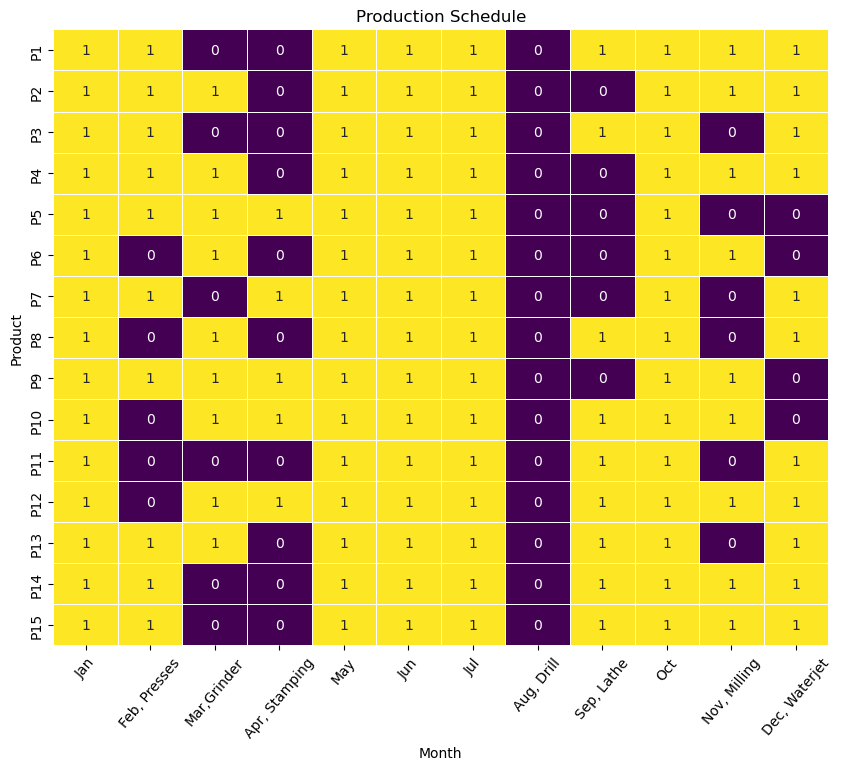

```python
import seaborn as sns

plt.figure(figsize=(10, 8))
heat = sns.heatmap(do, cmap='viridis', cbar=False, annot=True, fmt='g', linewidths=.5)
plt.title('Production Schedule')
plt.xlabel('Month')
plt.ylabel('Product')
month_machine = ['Jan', 'Feb, Presses', 'Mar,Grinder', 'Apr, Stamping', 'May', 'Jun', 'Jul', 'Aug, Drill', 'Sep, Lathe', 'Oct', 'Nov, Milling', 'Dec, Waterjet']
tick_positions = [i + 0.5 for i in range(len(month_machine))]
plt.xticks(ticks=tick_positions, labels=month_machine, rotation=50,ha="center")
plt.show()
```

Here we can see the impact of machine maintenance. The ones mean the product can be manufactured, the zeros represent that the praduct can not be manufactured. In the x axes we can see the machine that is in maintenance each month, so we can check that the products that depend on that machine can not be produced. We can also see that it is forbidden to do a maintenance in January as we have to make products of all types in order to satisfy the minimum demand.

```python
round(model.objective())
```

```
888902
```

We can see that the profit has decreased a lot. This make sense as we are limitating a lot the production.

```python
make = pd.DataFrame()

for i in model.I:
    for j in model.J:
        make.loc[i,j] = model.make[i,j]()


print(make)
```

```
        Jan     Feb     Mar     Apr     May     Jun     Jul  Aug     Sep  \
P1    900.0   450.0     0.0     0.0   700.0   600.0   800.0  0.0   421.0
P2    800.0   250.0   950.0     0.0   100.0   850.0   950.0  0.0     0.0
P3    650.0   650.0     0.0     0.0   600.0   850.0   600.0  0.0   450.0
P4    500.0   100.0   600.0     0.0   550.0   950.0   150.0  0.0     0.0
P5    550.0   450.0   250.0   550.0   700.0   800.0   500.0  0.0     0.0
P6   1150.0     0.0   300.0     0.0   850.0   850.0  1150.0  0.0     0.0
P7    350.0   550.0     0.0  1150.0   750.0   800.0   750.0  0.0     0.0
P8    700.0     0.0  1400.0     0.0   750.0  1050.0   600.0  0.0  1200.0
P9    800.0   650.0   950.0  1150.0  1150.0   600.0   700.0  0.0     0.0
P10   850.0     0.0  1300.0  1000.0  1000.0   650.0   500.0  0.0  1200.0
P11   450.0     0.0     0.0     0.0   750.0  1350.0  1100.0  0.0  1150.0
P12   850.0     0.0   700.0  1350.0  1350.0   550.0   750.0  0.0   600.0
P13   800.0   150.0   700.0     0.0  1450.0  1400.0  1050.0  0.0   950.0
P14   400.0  1100.0     0.0     0.0  1400.0   800.0  1050.0  0.0  1150.0
P15  1150.0   200.0     0.0     0.0   950.0  1300.0   600.0  0.0  1200.0

        Oct     Nov     Dec
P1    112.0   250.0   155.0
P2    700.0   950.0   650.0
P3    650.0     0.0   950.0
P4    600.0   100.0   700.0
P5    950.0     0.0     0.0
P6   1300.0   150.0     0.0
P7   1200.0     0.0   950.0
P8    850.0     0.0  1050.0
P9    750.0  1000.0     0.0
P10  1050.0  1300.0     0.0
P11   229.0     0.0  1315.0
P12  1050.0   800.0  1000.0
P13   327.0     0.0  1200.0
P14   850.0  1300.0  1350.0
P15   132.0  1000.0  1300.0
```

We can see that there are months where we do not produce products.

```python
sell = pd.DataFrame()

for i in model.I:
    for j in model.J:
        sell.loc[i,j] = model.sell[i,j]()


print(sell)
```

```
        Jan    Feb     Mar     Apr     May     Jun    Jul    Aug     Sep  \
P1    900.0  209.0   188.0    53.0   700.0   600.0  641.0  159.0   421.0
P2    800.0  250.0   666.0   196.0   188.0   850.0  667.0   84.0   199.0
P3    650.0  457.0    52.0   141.0   600.0   850.0  505.0   95.0   450.0
P4    468.0  132.0   461.0   139.0   550.0   108.0  663.0  159.0   170.0
P5    550.0  450.0   250.0   550.0   700.0   800.0  240.0  200.0    60.0
P6   1008.0  142.0   155.0   145.0   850.0   850.0  843.0  121.0   186.0
P7    350.0  402.0   148.0  1150.0   750.0   492.0  718.0  170.0   170.0
P8    636.0   64.0  1215.0   185.0   750.0  1050.0  523.0   77.0  1200.0
P9    800.0  650.0   950.0  1150.0  1150.0   600.0  477.0   79.0   144.0
P10   668.0  182.0  1300.0  1000.0  1000.0   650.0  307.0  193.0  1200.0
P11   110.0  185.0    89.0    66.0   750.0  1350.0  938.0  162.0  1150.0
P12   721.0  129.0   700.0  1350.0  1350.0   550.0  608.0  142.0   600.0
P13   776.0  174.0   592.0   108.0  1450.0  1400.0  894.0  156.0   950.0
P14   400.0  954.0    54.0    92.0  1400.0   800.0  882.0  168.0  1150.0
P15   902.0  186.0   166.0    96.0   950.0  1300.0  494.0  106.0  1200.0

        Oct     Nov     Dec
P1    112.0   250.0   155.0
P2    700.0   950.0   650.0
P3    470.0   180.0   950.0
P4    600.0   100.0   700.0
P5    750.0    77.0   123.0
P6    153.0  1179.0   118.0
P7    174.0  1026.0   950.0
P8    617.0   233.0  1050.0
P9    750.0   902.0    98.0
P10  1050.0  1209.0    91.0
P11   102.0   127.0  1315.0
P12  1050.0   800.0  1000.0
P13   240.0    87.0  1200.0
P14   850.0  1300.0  1350.0
P15   132.0  1000.0  1300.0
```

```python
store = pd.DataFrame()

for i in model.I:
    for j in model.J:
        store.loc[i,j] = model.store[i,j]()


print(store)
```

```
       Jan    Feb    Mar   Apr  May    Jun    Jul    Aug  Sep     Oct    Nov  \
P1     0.0  241.0   53.0   0.0  0.0    0.0  159.0    0.0  0.0     0.0    0.0
P2     0.0    0.0  284.0  88.0  0.0    0.0  283.0  199.0  0.0     0.0    0.0
P3     0.0  193.0  141.0   0.0  0.0    0.0   95.0    0.0  0.0   180.0    0.0
P4    32.0    0.0  139.0   0.0  0.0  842.0  329.0  170.0  0.0     0.0    0.0
P5     0.0    0.0    0.0   0.0  0.0    0.0  260.0   60.0  0.0   200.0  123.0
P6   142.0    0.0  145.0   0.0  0.0    0.0  307.0  186.0  0.0  1147.0  118.0
P7     0.0  148.0    0.0   0.0  0.0  308.0  340.0  170.0  0.0  1026.0    0.0
P8    64.0    0.0  185.0   0.0  0.0    0.0   77.0    0.0  0.0   233.0    0.0
P9     0.0    0.0    0.0   0.0  0.0    0.0  223.0  144.0  0.0     0.0   98.0
P10  182.0    0.0    0.0   0.0  0.0    0.0  193.0    0.0  0.0     0.0   91.0
P11  340.0  155.0   66.0   0.0  0.0    0.0  162.0    0.0  0.0   127.0    0.0
P12  129.0    0.0    0.0   0.0  0.0    0.0  142.0    0.0  0.0     0.0    0.0
P13   24.0    0.0  108.0   0.0  0.0    0.0  156.0    0.0  0.0    87.0    0.0
P14    0.0  146.0   92.0   0.0  0.0    0.0  168.0    0.0  0.0     0.0    0.0
P15  248.0  262.0   96.0   0.0  0.0    0.0  106.0    0.0  0.0     0.0    0.0

     Dec
P1   0.0
P2   0.0
P3   0.0
P4   0.0
P5   0.0
P6   0.0
P7   0.0
P8   0.0
P9   0.0
P10  0.0
P11  0.0
P12  0.0
P13  0.0
P14  0.0
P15  0.0
```

We also see that now we have to store more products.

### Final conclusions

In this project I had formulated, implemented and solved an optimization problem. In the first part this problem was linear and in the second one we introduce some new decision variables in order to make it also a discrete problem. I have also analyzed the sensitivities and checked their meaning by creating a new model where I increased the analyzed constraint.

The idea of the project was to optimize the production/selling/storing planning in months of a factory for a year. I have choosen this topic because I wanted to explore a case that we have not seen a lot in the subject. This factory manufacture 15 different products, so I had 540 decision variables. Once I had the idea of the problem I had to create realistic constraints to make the problem bounded, note that in real life this type of problems can have more constraints and more decision variables which will make the problem more complex. After having defined the problem I had to obtain data to be able to solve the problem. I was not able to find data about factory planning so I have invented the values. This was the most complicated part as I had to introduce all the data by hand and because as it was invented I had to make a lot of trying to have realistic values in the constraints, this means that I have to avoid creating constraints values that limitates the range of the solutions of the decision variables. Then I solved the problem using Gurobi solver as it is much faster than glpk, and interpret the results, checking that they were realistic and satisfying all the constraints. For the second part I have followed the same approach.

In conclusion, I have enjoyed a lot this project as it was very practical and realistic and I had learnt a lot about linear and discrete optimization problems.